# Deliverable-3

### **2. How does TV spending(investment) affect sales? Can you quantify it?**

Hint: Company has invested for 2-week, 5-time impressions of Tv promotion, total investment is $15000

Number of population reach is 25% of 50000. Out of 25% only 12% population buy $1500 sales.

```r
# Calculating the population:
Population <- 50000 * (25/100)

# 12 % of population buy $1,500
Buyers <- Population * (12/100)
SalesAfterTV_ADV <- 1500

# Getting the pre-sales before TV advertisements
SalesBeforeTV_ADV <- sum(Purchases$price)

# Total investment in TV advertisments = $15,000
InvestmentTV <- 15000

# Calculating the profit
Profit <- SalesAfterTV_ADV - InvestmentTV

# Calculation of sales growth rate
GrowTV <- 100*round(SalesAfterTV_ADV / SalesBeforeTV_ADV, 2)


# Print the calcules
print(paste("Sales Before TV Advertisments =","$",SalesBeforeTV_ADV))
```

```
[1] "Sales Before TV Advertisments = $ 10009.39"
```

```r
print(paste("Sales After TV Advertisments =","$",SalesAfterTV_ADV))
```

```
[1] "Sales After TV Advertisments = $ 1500"
```

```r
print(paste("Sales Growth Rate =",GrowTV, "%"))
```

```
[1] "Sales Growth Rate = 15 %"
```

```r
print("------------------------------------------")
```

```
[1] "------------------------------------------"
```

```r
print(paste("Profit =","$",Profit))
```

```
[1] "Profit = $ -13500"
```

```r
print("------------------------------------------")
```

```
[1] "------------------------------------------"
```

```r
print("After investment 15,000  the new sales = 1,500")
```

```
[1] "After investment 15,000  the new sales = 1,500"
```

```r
print("***** The company lost $13.500 *****")
```

```
[1] "***** The company lost $13.500 *****"
```

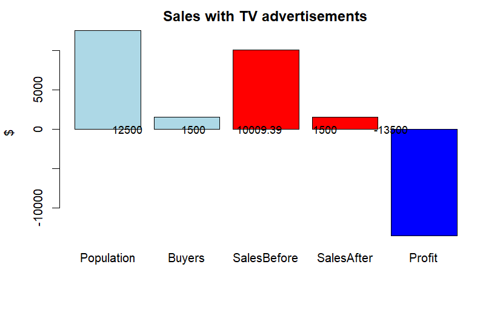

```r
x = c(12500, 1500, 10009.39, 1500, -13500)
labels=c("Population", "Buyers", "SalesBefore", "SalesAfter", "Profit")
graph2 <- barplot(x, names.arg=labels, border="black", col=c("lightblue", "lightblue", "red", "red", "blue"), xlab="", ylab="$", main="Sales with TV advertisements")
text(graph2, paste(x) ,cex=0.9)
```

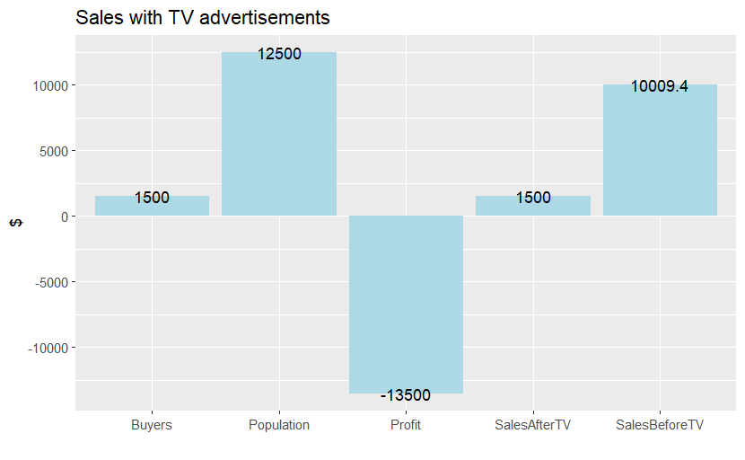

```r
set.seed(5642)
graph3 <- data.frame(name = c("Population", "Buyers", "SalesBeforeTV",
                              "SalesAfterTV", "Profit") ,
                     value = c(12500, 1500, 10009.39, 1500, -13500))
library("ggplot2")

plot<-ggplot(graph3,aes(name,value)) +
geom_bar(stat = "identity", fill="lightblue") +
geom_text(aes(label = signif(value)), nudge_y = 3) +
labs(title = "Sales with TV advertisements") +
xlab("") + ylab("$")
plot
```

3. **How does Radio spending affect sales? Can you quantify it?**

   Hint: Company has invested for 1-week,3-time impressions of Tv promotion, total investment is $15000

```r
# Calculating the population:
Population <- 50000 * (10/100)

# 5 % of population buy $500
Buyers <- Population * (5/100)
SalesAfterRadio_ADV <- 500

# Getting the pre-sales before Radio advertisements
SalesBeforeRadio_ADV <- sum(Purchases$price)

# Total investment in Radio advertisments = $15,000
InvestmentRD <- 15000

# Calculating the profit
Profit <- SalesAfterRadio_ADV - InvestmentRD

# Calculation of sales growth rate
GrowRD <- 100 * round(SalesAfterRadio_ADV / SalesBeforeRadio_ADV, 2)

# Print the calcules
print(paste("Sales Before Radio Advertisments =","$",SalesBeforeRadio_ADV))
```

```
[1] "Sales Before Radio Advertisments = $ 10009.39"
```

```r
print(paste("Sales After Radio Advertisments =","$",SalesAfterRadio_ADV))
```

```
[1] "Sales After Radio Advertisments = $ 500"
```

```r
print(paste("Sales Growth Rate =",GrowRD, "%"))
```

```
[1] "Sales Growth Rate = 5 %"
```

```r
print("------------------------------------------")
```

```
[1] "------------------------------------------"
```

```r
print(paste("Profit =","$",Profit))
```

```
[1] "Profit = $ -14500"
```

```r
print("------------------------------------------")
```

```
[1] "------------------------------------------"
```

```r
print("After investment 15,000  the new sales = 500")
```

```
[1] "After investment 15,000  the new sales = 500"
```

```r
print("***** The company lost $14.500 *****")
```

```
[1] "***** The company lost $14.500 *****"
```

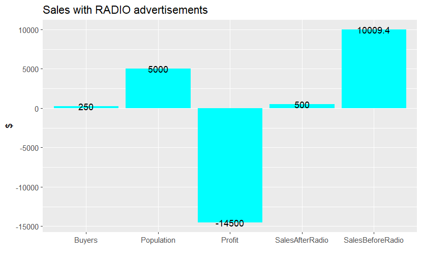

```r
set.seed(5642)
graph4 <- data.frame(name = c("Population", "Buyers", "SalesBeforeRadio",
                              "SalesAfterRadio", "Profit") ,
                     value = c(5000, 250, 10009.39, 500, -14500))
library("ggplot2")

plot<-ggplot(graph4,aes(name,value)) +
geom_bar(stat = "identity", fill="cyan") +
geom_text(aes(label = signif(value)), nudge_y = 3) +
labs(title = "Sales with RADIO advertisements") +
xlab("") + ylab("$")
plot
```

### **4.** Calculate the ROI for each investment

```r
#ROI = ((Sales Growth-Marketing Cost) / Marketing Cost) * 100%

SalesGrowthTV <- SalesAfterTV_ADV - SalesBeforeTV_ADV
ROI_TV <- round(SalesGrowthTV / InvestmentTV *100, 2)

SalesGrowthRD <- SalesAfterRadio_ADV - SalesBeforeRadio_ADV
ROI_RD <- round(SalesGrowthRD / InvestmentRD *100, 2)

print(paste("ROI for TV Investment =",ROI_TV, "%"))
```

```
[1] "ROI for TV Investment = -56.73 %"
```

```r
print(paste("ROI for Radio Investment =",ROI_RD, "%"))
```

```
[1] "ROI for Radio Investment = -63.4 %"
```

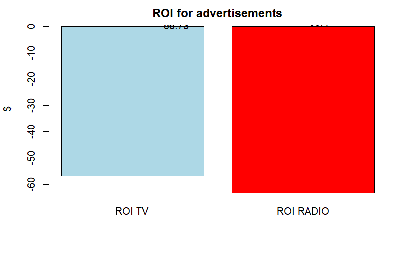

```r
x = c(ROI_TV, ROI_RD)
labels=c("ROI TV", "ROI RADIO")
graph2 <- barplot(x, names.arg=labels, border="black", col=c("lightblue","red"), xlab="", ylab="$", main="ROI for advertisements")
text(graph2, paste(x) ,cex=1)
```